# STA 6856 Time Series

Final Exam

Author

Student Name

## Instructions

The take-home project exam will involve analyzing time series data. You are allowed to use your notes, the lectures notes, and anything you find in the library or online, if that is properly acknowledged, but all your work must be your own. **Complete this examination honestly, without giving assistance to anyone or receiving it from anyone.**

**⚠️ Late Submission are not accepted.**

```r
library(datasets)
library(itsmr)
library(forecast)
```

# Problem A: Application of ACF (Estimation)

1. Find (show derivations) the autocovariance (ACVF) and the autocorrelation (ACF) functions of MA(1) time series model.
2. In this second part, we will study how the sample size (time series length) is associated with the estimation of $\theta$ for an MA(1) model. Use R to simulate 500 series of length n = {5, 25, 50, 75, 100, 150, 200, 500} of an MA(1) process with $\theta =0.6$ given by:

$$X_t = 0.6Z_{t−1} + Z_t, \text{ where } Z_t ∼ W N (0, 1)$$

2.1. Compute the estimate of $\rho(1)$ using `acf()` function for each series and sample size.

2.2. Plot densities of the estimates using `geom_density` for each sample size all together in the plot.

2.3. Give a box plot of the estimates using `geom_boxplot` for each sample size all together in the plot.

2.4. Compute and provide in a table the mean and standard deviation of the estimates for each sample size.

2.5. Use this simulation study to find the smallest sample size where the mean square error of the estimation $\sum (0.6-estimate)^2 / 500 < 0.001$; 500 is the number of simulation runs.

# Problem B (Modeling and Forecasting)

We are going to study the monthly deaths from Lung Diseases (bronchitis, emphysema and asthma) in the UK, from 1974 to 1979. There are three data sets: 1) `ldeaths` contains the total monthly deaths, 2) `mdeaths` has only males monthly deaths and 3) `fdeaths` has females monthly deaths. Note that ldeaths= fdeaths+ mdeaths.

You can find these datasets in `datasets` package. The goal is to build a model for forecasting the monthly deaths from Lung Diseases in the UK. The following are the steps you should consider in your analysis:

1. Split each dataset to 2 datasets: i) The Training dataset will contain observations from 1974 to 1978 and ii) the Testing dataset will have the data of 1979.

```r
# 01- Monthly deaths
# Training Split
deaths_training <- window(ldeaths, start = c(1974, 1), end = c(1978, 12))

# Creating a time series
death_training_ts <- ts(deaths_training, frequency = 12)


# 02- Male deaths
# Training Split
male_training <- window(mdeaths, start = c(1974, 1), end = c(1978, 12))

# Creating a time series
male_training_ts <- ts(male_training, frequency = 12)

# 03- Female deaths
# Training Split
female_training <- window(fdeaths, start = c(1974, 1), end = c(1978, 12))

# Creating a time series
female_training_ts <- ts(female_training, frequency = 12)
```

2. Fit a time series model to the training `ldeaths` data set (Plot the data, ACF, and PACF. Describe and discuss the steps you followed), and write down the equation of the model.

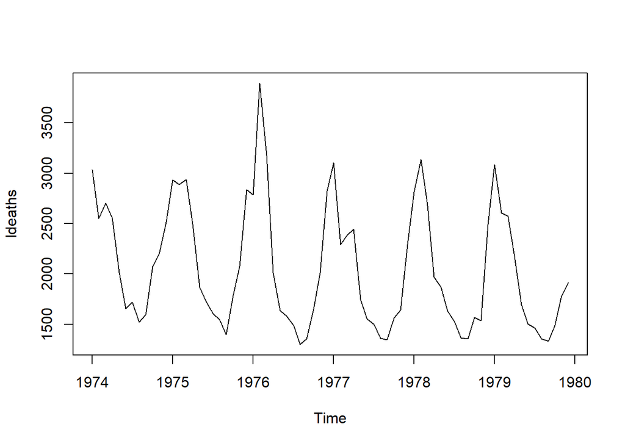

```r
plot(ldeaths)
```

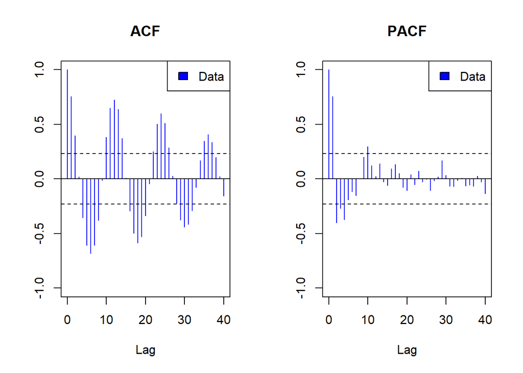

```r
plota(ldeaths)
```

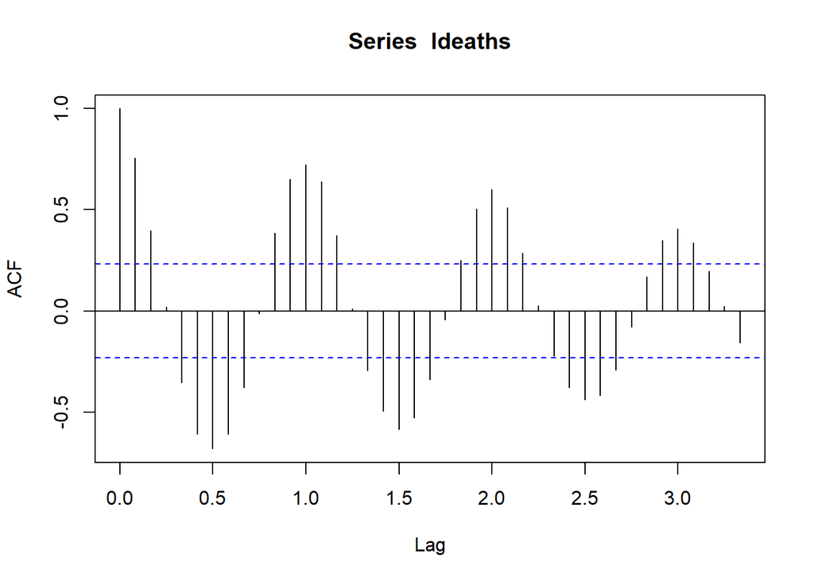

```r
acf(ldeaths, lag.max = 40)
```

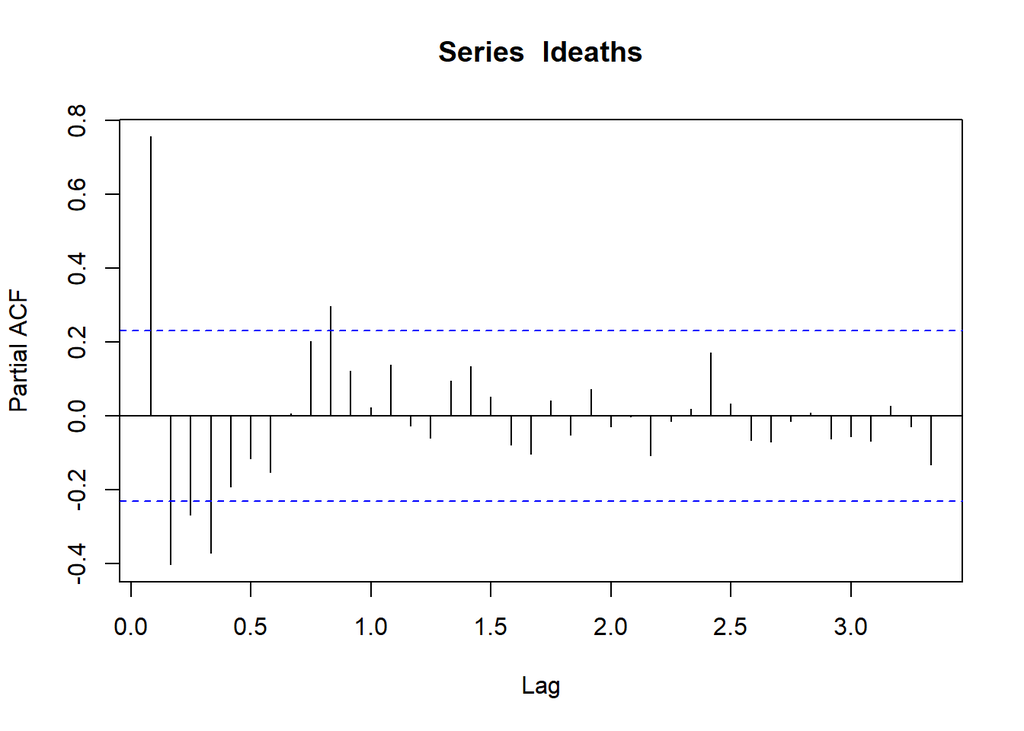

```r
pacf(ldeaths, lag.max = 40)
```

- It seems that there is no trend.
- There is seasonality of 12.
- Overall, no drastic variance change, except in 1976. Further inspection is needed.

  ```r
  library(car)
  # Variance change transformation
  lambda = powerTransform(ldeaths)
  lambda$roundlam
  ```

  ```
  ldeaths
        0
  ```

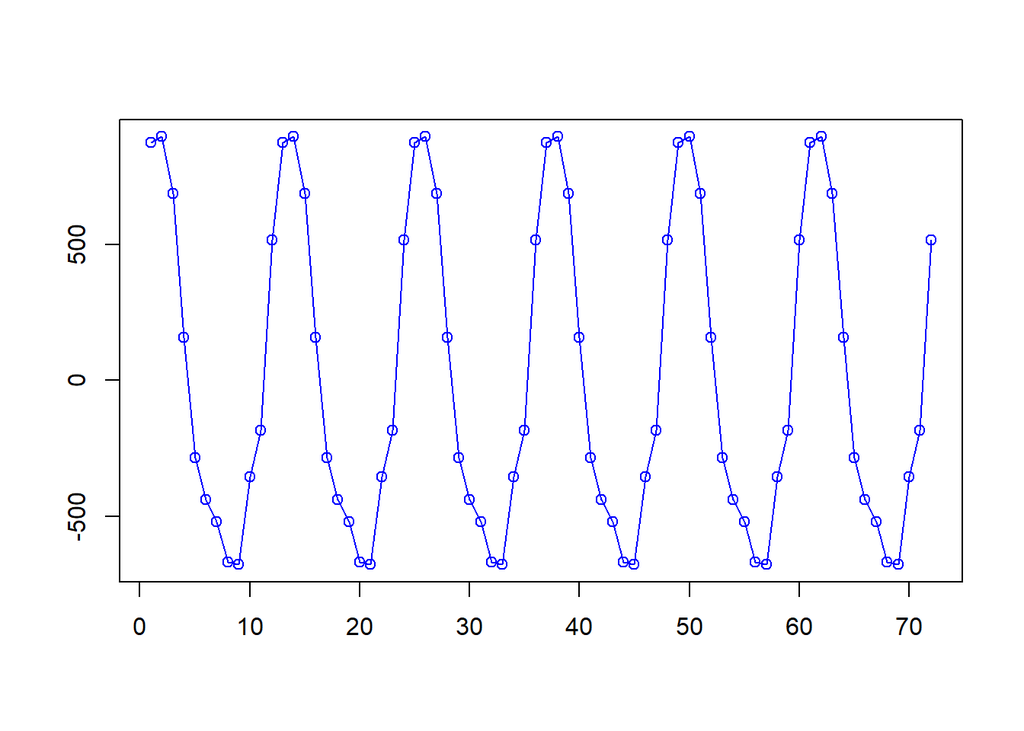

  ```r
  # Seasonality
  deaths_season = season(ldeaths, d=12)
  plotc(deaths_season)
  ```

## Test IID

```
Null hypothesis: Residuals are iid noise.
Test                        Distribution Statistic   p-value
Ljung-Box Q                Q ~ chisq(20)     66.76         0 *
McLeod-Li Q                Q ~ chisq(20)     51.01     2e-04 *
Turning points T     (T-38)/3.2 ~ N(0,1)        36    0.5305
Diff signs S         (S-29)/2.2 ~ N(0,1)        28    0.6547
Rank P           (P-855.5)/76.5 ~ N(0,1)       849    0.9323
```

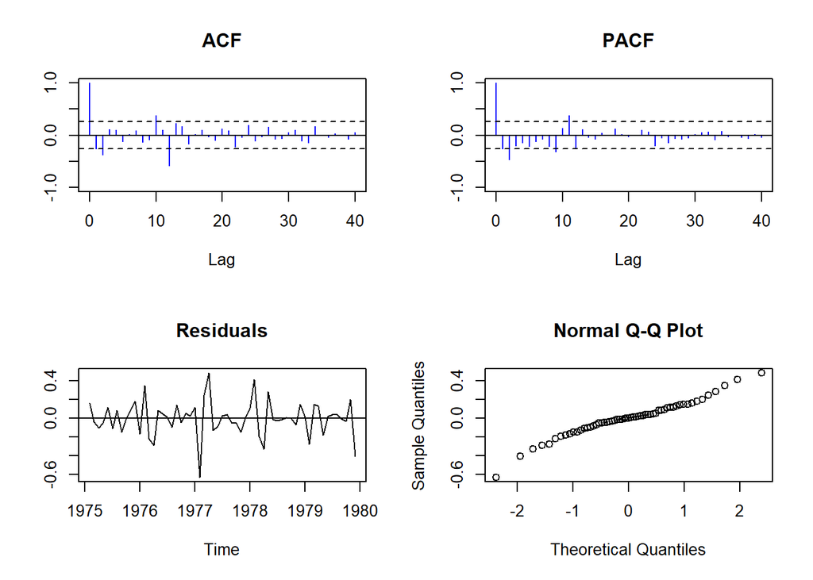

```r
# Differencing Operator
deaths_diff = c("log","diff", 12, "diff", 1)

# IID hypothesis test
deaths_r_diff = Resid(ldeaths, deaths_diff)
test(deaths_r_diff)
```

## Stationary Hypothesis

```r
library(aTSA)
# Stationary Test
adf.test(deaths_r_diff)
```

```
Augmented Dickey-Fuller Test
alternative: stationary

Type 1: no drift no trend
     lag    ADF p.value
[1,]   0  -9.73    0.01
[2,]   1 -10.01    0.01
[3,]   2  -7.27    0.01
[4,]   3  -6.08    0.01
Type 2: with drift no trend
     lag   ADF p.value
[1,]   0 -9.64    0.01
[2,]   1 -9.92    0.01
[3,]   2 -7.21    0.01
[4,]   3 -6.03    0.01
Type 3: with drift and trend
     lag   ADF p.value
[1,]   0 -9.55    0.01
[2,]   1 -9.82    0.01
[3,]   2 -7.12    0.01
[4,]   3 -5.94    0.01
----
Note: in fact, p.value = 0.01 means p.value <= 0.01
```

### Based on the PACF

P = 0, 1:4, 10

p = 0,1

### Based on the ACF

q = 0, 1, 2, 4:8, 10:14

Q = 0,1:3

### Eliminate Season

d = 0 (differencing non-seasonal)

D = 1 (differencing seasonal)

## Autofit - Deaths

```r
# Auto fit
deaths_bestmodel = auto.arima(ldeaths, trace = T)
```

```
 ARIMA(2,0,2)(1,1,1)[12] with drift         : Inf
 ARIMA(0,0,0)(0,1,0)[12] with drift         : 880.4252
 ARIMA(1,0,0)(1,1,0)[12] with drift         : 859.3667
 ARIMA(0,0,1)(0,1,1)[12] with drift         : Inf
 ARIMA(0,0,0)(0,1,0)[12]                    : 879.5963
 ARIMA(1,0,0)(0,1,0)[12] with drift         : 882.3707
 ARIMA(1,0,0)(2,1,0)[12] with drift         : 850.3567
 ARIMA(1,0,0)(2,1,1)[12] with drift         : Inf
 ARIMA(1,0,0)(1,1,1)[12] with drift         : Inf
 ARIMA(0,0,0)(2,1,0)[12] with drift         : 849.4512
 ARIMA(0,0,0)(1,1,0)[12] with drift         : 858.6241
 ARIMA(0,0,0)(2,1,1)[12] with drift         : Inf
 ARIMA(0,0,0)(1,1,1)[12] with drift         : Inf
 ARIMA(0,0,1)(2,1,0)[12] with drift         : 848.6208
 ARIMA(0,0,1)(1,1,0)[12] with drift         : 857.257
 ARIMA(0,0,1)(2,1,1)[12] with drift         : Inf
 ARIMA(0,0,1)(1,1,1)[12] with drift         : Inf
 ARIMA(1,0,1)(2,1,0)[12] with drift         : 849.8721
 ARIMA(0,0,2)(2,1,0)[12] with drift         : 848.2589
 ARIMA(0,0,2)(1,1,0)[12] with drift         : 855.7322
 ARIMA(0,0,2)(2,1,1)[12] with drift         : Inf
 ARIMA(0,0,2)(1,1,1)[12] with drift         : Inf
 ARIMA(1,0,2)(2,1,0)[12] with drift         : Inf
 ARIMA(0,0,3)(2,1,0)[12] with drift         : 849.0507
 ARIMA(1,0,3)(2,1,0)[12] with drift         : 851.4635
 ARIMA(0,0,2)(2,1,0)[12]                    : 857.4225

 Best model: ARIMA(0,0,2)(2,1,0)[12] with drift
```

```r
#SARIMA (0,0,2)(2,1,0)12
```

```r
# Fit 1
deaths_fit1 = arima(ldeaths,
             order = c(0,0,2),
             seasonal = list(order=c(1,1,1), period=12))

# Fit 2
deaths_fit2 = arima(ldeaths,
             order = c(0,0,2),
             seasonal = list(order=c(1,1,3), period=12))

# Fit 3
deaths_fit3 = arima(ldeaths,
             order = c(0,0,2),
             seasonal = list(order=c(1,1,2), period=12))
```

## Check Residuals from SARIMA models

```
Null hypothesis: Residuals are iid noise.
Test                        Distribution Statistic   p-value
Ljung-Box Q                Q ~ chisq(20)     12.44    0.9001
McLeod-Li Q                Q ~ chisq(20)      2.56         1
Turning points T   (T-46.7)/3.5 ~ N(0,1)        46    0.8503
Diff signs S       (S-35.5)/2.5 ~ N(0,1)        36    0.8394
Rank P           (P-1278)/102.9 ~ N(0,1)      1311    0.7483
```

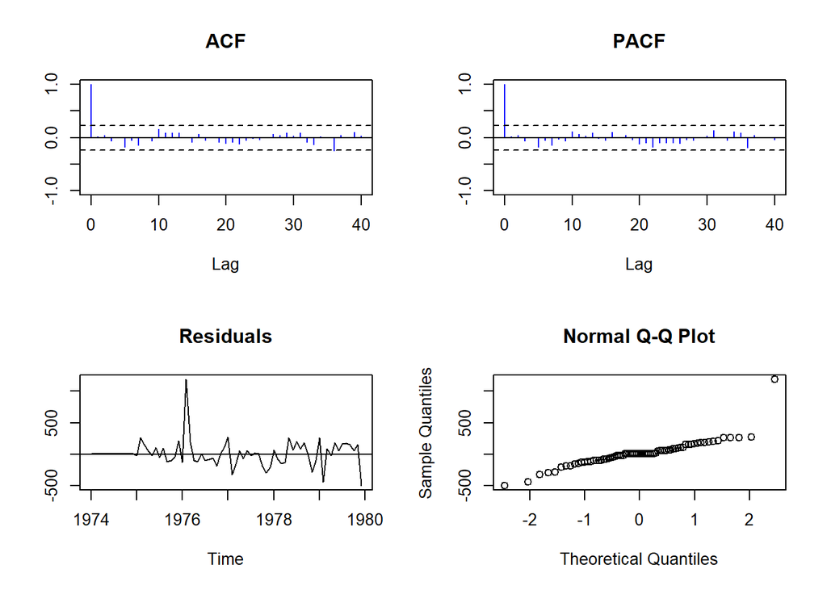

```r
# autofit
test(deaths_bestmodel$residuals)
```

```r
confint(deaths_bestmodel)
```

```
           2.5 %      97.5 %
ma1   -0.1071427  0.47590635
ma2   -0.5356149  0.04029154
sar1  -1.2130367 -0.69364059
sar2  -0.7580496 -0.24666539
drift -7.7763389 -3.27762515
```

```
Null hypothesis: Residuals are iid noise.
Test                        Distribution Statistic   p-value
Ljung-Box Q                Q ~ chisq(20)      9.23    0.9801
McLeod-Li Q                Q ~ chisq(20)      10.5    0.9581
Turning points T   (T-46.7)/3.5 ~ N(0,1)        46    0.8503
Diff signs S       (S-35.5)/2.5 ~ N(0,1)        37    0.5431
Rank P           (P-1278)/102.9 ~ N(0,1)      1040    0.0207 *
```

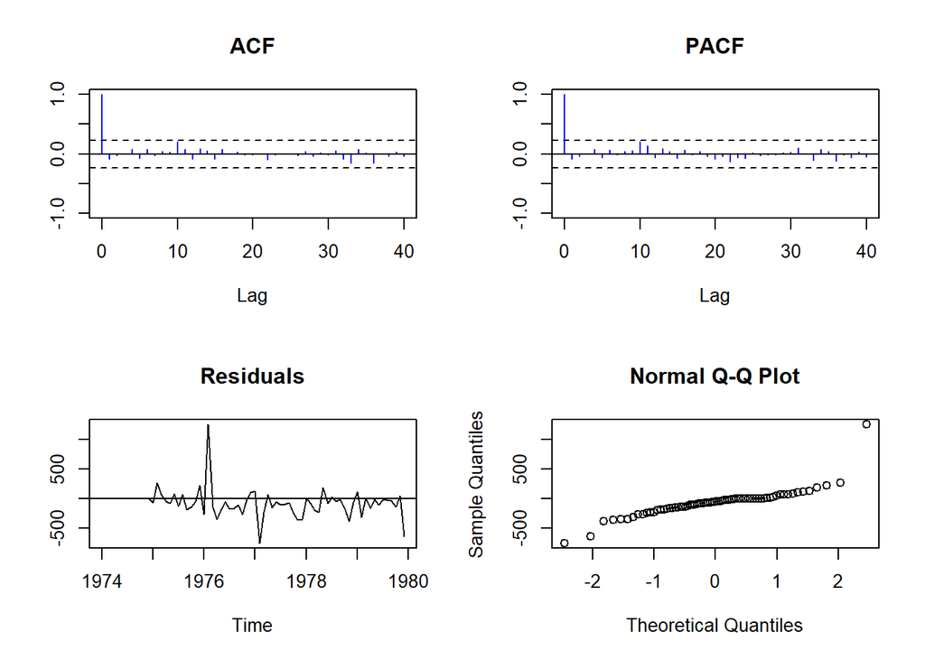

```r
# Fit 1
test(deaths_fit1$residuals)
```

```r
confint(deaths_fit1)
```

```
           2.5 %     97.5 %
ma1   0.09521611 0.69162355
ma2  -0.33857224 0.19120700
sar1 -0.71707283 0.01602566
sma1 -0.98298024 0.03287004
```

```
Null hypothesis: Residuals are iid noise.
Test                        Distribution Statistic   p-value
Ljung-Box Q                Q ~ chisq(20)      8.78    0.9854
McLeod-Li Q                Q ~ chisq(20)     10.65    0.9547
Turning points T   (T-46.7)/3.5 ~ N(0,1)        46    0.8503
Diff signs S       (S-35.5)/2.5 ~ N(0,1)        37    0.5431
Rank P           (P-1278)/102.9 ~ N(0,1)      1038    0.0196 *
```

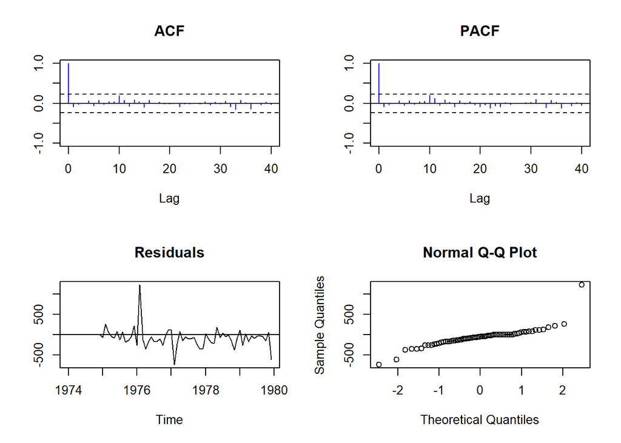

```r
# Fit 2
test(deaths_fit2$residuals)
```

```r
confint(deaths_fit2)
```

```
           2.5 %    97.5 %
ma1   0.09096597 0.6873722
ma2  -0.33629959 0.1986670
sar1 -2.77602651 3.2301863
sma1 -4.88143564 2.6936849
sma2 -2.18120285 3.1528070
sma3 -1.57030897 1.1073159
```

```
Null hypothesis: Residuals are iid noise.
Test                        Distribution Statistic   p-value
Ljung-Box Q                Q ~ chisq(20)       9.1    0.9817
McLeod-Li Q                Q ~ chisq(20)     10.29    0.9625
Turning points T   (T-46.7)/3.5 ~ N(0,1)        46    0.8503
Diff signs S       (S-35.5)/2.5 ~ N(0,1)        37    0.5431
Rank P           (P-1278)/102.9 ~ N(0,1)      1045    0.0235 *
```

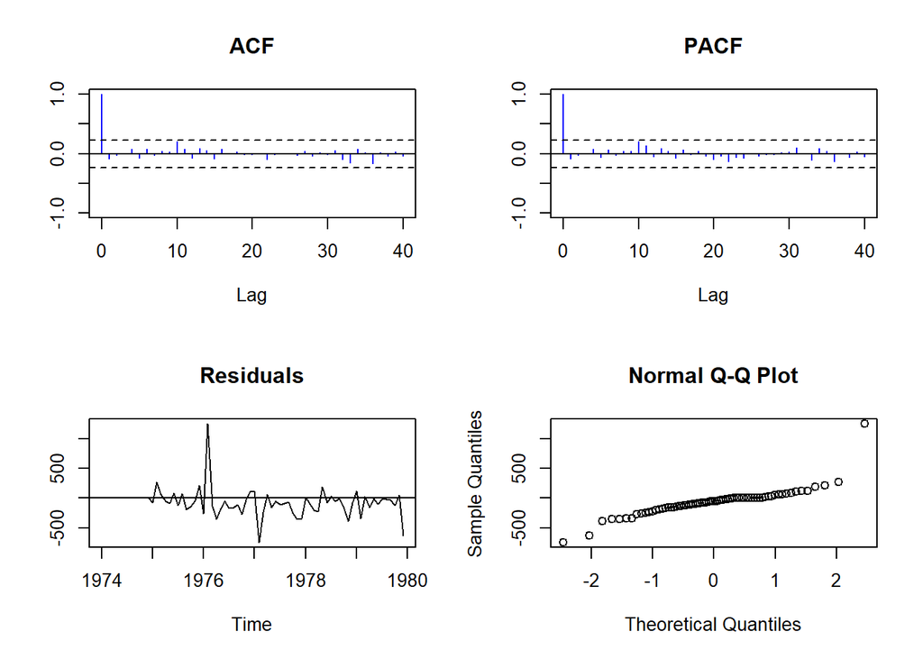

```r
# Fit 3
test(deaths_fit3$residuals)
```

```r
confint(deaths_fit3)
```

```
           2.5 %    97.5 %
ma1   0.09173332 0.6903585
ma2  -0.34112989 0.1898485
sar1 -1.29135033 0.7601001
sma1 -1.58799979 0.4777854
sma2 -0.86502847 1.0403802
```

- The best model is the SARIMA (0,0,2)(2,1,0)12
- The other fitted models did not pass the hypothesis test.

3. Fit a time series model to the training `mdeaths` data set Plot the data, ACF, and PACF. Describe and discuss the steps you followed), and write down the equation of the model.

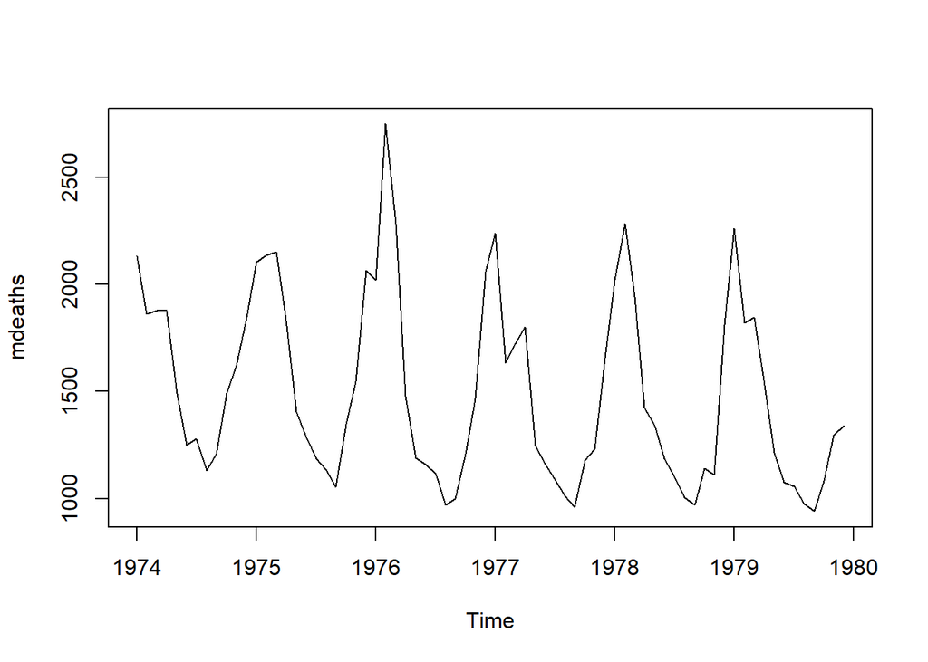

```r
plot(mdeaths)
```

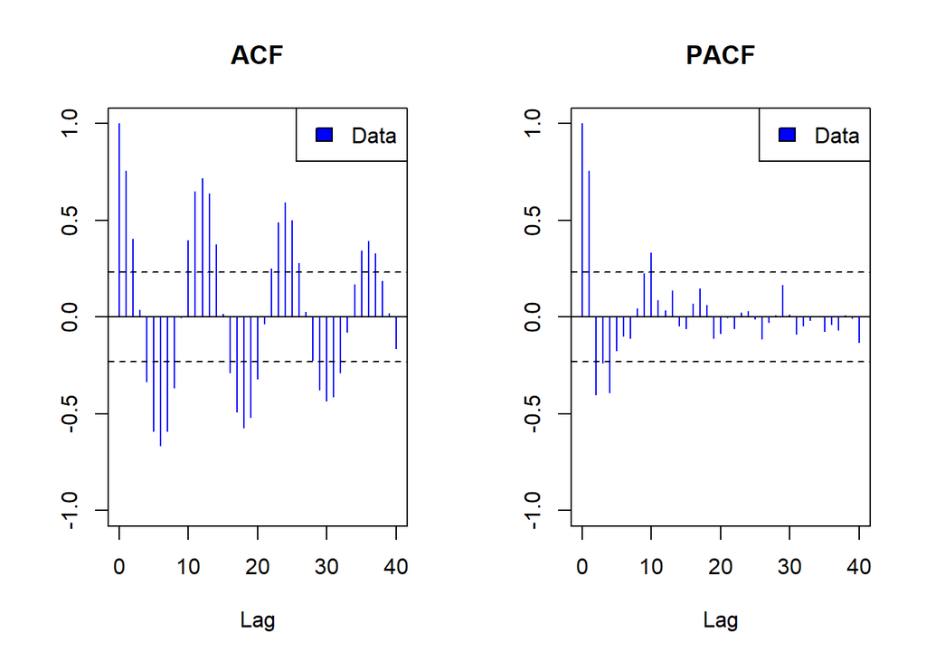

```r
plota(mdeaths)
```

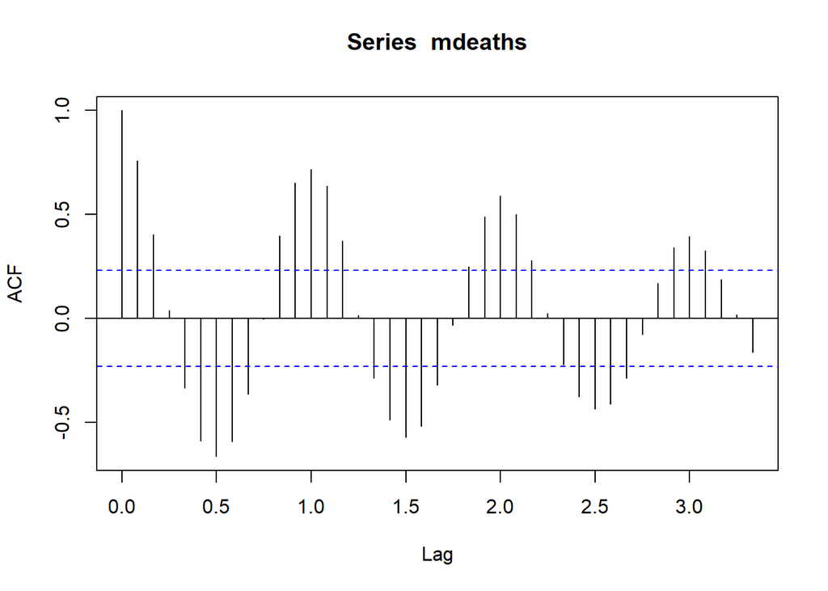

```r
acf(mdeaths, lag.max = 40)
```

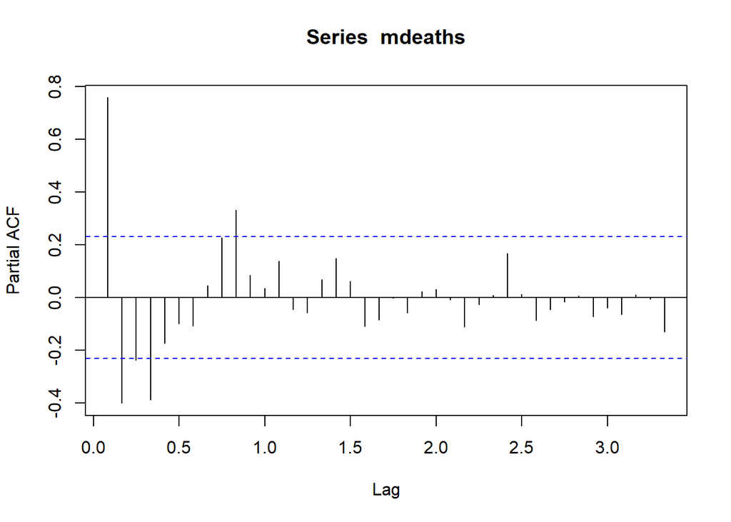

```r
pacf(mdeaths, lag.max = 40)
```

- It seems that there is no trend.
- There is seasonality of 12.
- There is a variance change in 1976. Further inspection is needed.

```r
# Variance change transformation
lambda = powerTransform(mdeaths)
lambda$roundlam
```

```
mdeaths
      0
```

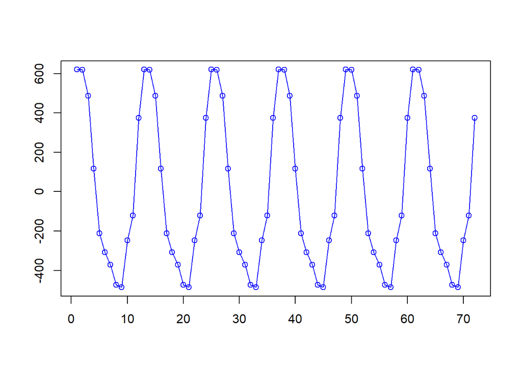

```r
# Seasonality
male_season = season(mdeaths, d=12)
plotc(male_season)
```

## IID - Male

```
Null hypothesis: Residuals are iid noise.
Test                        Distribution Statistic   p-value
Ljung-Box Q                Q ~ chisq(20)     71.66         0 *
McLeod-Li Q                Q ~ chisq(20)     55.33         0 *
Turning points T     (T-38)/3.2 ~ N(0,1)        36    0.5305
Diff signs S         (S-29)/2.2 ~ N(0,1)        29         1
Rank P           (P-855.5)/76.5 ~ N(0,1)       844    0.8804
```

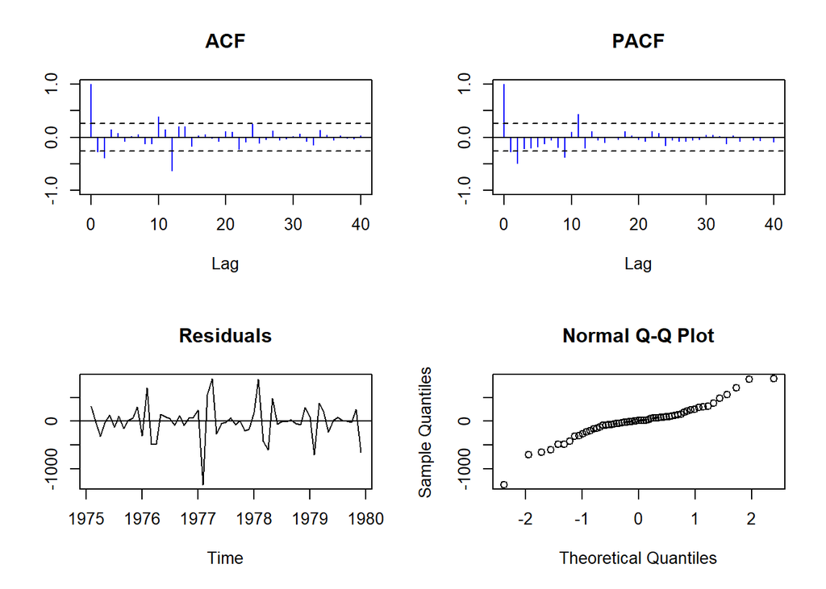

```r
# Differencing Operator
male_diff = c("diff", 12, "diff", 1)

# IID hypothesis test
male_r_diff = Resid(mdeaths, male_diff)
test(male_r_diff)
```

## Stationary Hypothesis - Male

```r
# Stationary Test
adf.test(male_r_diff)
```

```
Augmented Dickey-Fuller Test
alternative: stationary

Type 1: no drift no trend
     lag    ADF p.value
[1,]   0  -9.86    0.01
[2,]   1 -10.39    0.01
[3,]   2  -7.44    0.01
[4,]   3  -6.47    0.01
Type 2: with drift no trend
     lag    ADF p.value
[1,]   0  -9.77    0.01
[2,]   1 -10.29    0.01
[3,]   2  -7.37    0.01
[4,]   3  -6.42    0.01
Type 3: with drift and trend
     lag    ADF p.value
[1,]   0  -9.68    0.01
[2,]   1 -10.19    0.01
[3,]   2  -7.29    0.01
[4,]   3  -6.33    0.01
----
Note: in fact, p.value = 0.01 means p.value <= 0.01
```

### Based on the PACF - Male

P = 0, 1:4, 10

p = 0,1

### Based on the ACF - Male

q = 0, 1, 2, 4:8, 10:14

Q = 0,1:3

### Eliminate Season - Male

d = 0 (differencing non-seasonal)

D = 1 (differencing seasonal)

## Autofit - Male

```r
# Auto fit
male_bestmodel = auto.arima(mdeaths, trace = T)
```

```
 ARIMA(2,0,2)(1,1,1)[12] with drift         : 812.6957
 ARIMA(0,0,0)(0,1,0)[12] with drift         : 841.5768
 ARIMA(1,0,0)(1,1,0)[12] with drift         : 819.3659
 ARIMA(0,0,1)(0,1,1)[12] with drift         : Inf
 ARIMA(0,0,0)(0,1,0)[12]                    : 841.1271
 ARIMA(2,0,2)(0,1,1)[12] with drift         : Inf
 ARIMA(2,0,2)(1,1,0)[12] with drift         : 818.5493
 ARIMA(2,0,2)(2,1,1)[12] with drift         : Inf
 ARIMA(2,0,2)(1,1,2)[12] with drift         : Inf
 ARIMA(2,0,2)(0,1,0)[12] with drift         : 842.6886
 ARIMA(2,0,2)(0,1,2)[12] with drift         : 812.7409
 ARIMA(2,0,2)(2,1,0)[12] with drift         : Inf
 ARIMA(2,0,2)(2,1,2)[12] with drift         : Inf
 ARIMA(1,0,2)(1,1,1)[12] with drift         : Inf
 ARIMA(2,0,1)(1,1,1)[12] with drift         : 810.2523
 ARIMA(2,0,1)(0,1,1)[12] with drift         : Inf
 ARIMA(2,0,1)(1,1,0)[12] with drift         : 816.1449
 ARIMA(2,0,1)(2,1,1)[12] with drift         : 812.8359
 ARIMA(2,0,1)(1,1,2)[12] with drift         : 812.8829
 ARIMA(2,0,1)(0,1,0)[12] with drift         : 840.777
 ARIMA(2,0,1)(0,1,2)[12] with drift         : 810.4495
 ARIMA(2,0,1)(2,1,0)[12] with drift         : 810.15
 ARIMA(1,0,1)(2,1,0)[12] with drift         : 810.1285
 ARIMA(1,0,1)(1,1,0)[12] with drift         : 817.3854
 ARIMA(1,0,1)(2,1,1)[12] with drift         : Inf
 ARIMA(1,0,1)(1,1,1)[12] with drift         : Inf
 ARIMA(0,0,1)(2,1,0)[12] with drift         : 808.6436
 ARIMA(0,0,1)(1,1,0)[12] with drift         : 816.47
 ARIMA(0,0,1)(2,1,1)[12] with drift         : Inf
 ARIMA(0,0,1)(1,1,1)[12] with drift         : Inf
 ARIMA(0,0,0)(2,1,0)[12] with drift         : 809.8688
 ARIMA(0,0,2)(2,1,0)[12] with drift         : 808.7496
 ARIMA(1,0,0)(2,1,0)[12] with drift         : 810.5831
 ARIMA(1,0,2)(2,1,0)[12] with drift         : Inf
 ARIMA(0,0,1)(2,1,0)[12]                    : 817.0729

 Best model: ARIMA(0,0,1)(2,1,0)[12] with drift
```

```r
# Fit 1
male_fit1 = arima(mdeaths,
             order = c(0,0,10),
             seasonal = list(order=c(2,1,0), period=12))

# Fit 2
male_fit2 = arima(mdeaths,
             order = c(0,0,12),
             seasonal = list(order=c(2,1,0), period=12))

# Fit 3
male_fit3 = arima(mdeaths,
             order = c(0,0,10),
             seasonal = list(order=c(2,1,1), period=12))
```

## Test Residuals from Male SARIMA models

```
Null hypothesis: Residuals are iid noise.
Test                        Distribution Statistic   p-value
Ljung-Box Q                Q ~ chisq(20)     10.72    0.9532
McLeod-Li Q                Q ~ chisq(20)      6.31    0.9984
Turning points T   (T-46.7)/3.5 ~ N(0,1)        42    0.1865
Diff signs S       (S-35.5)/2.5 ~ N(0,1)        37    0.5431
Rank P           (P-1278)/102.9 ~ N(0,1)      1259    0.8534
```

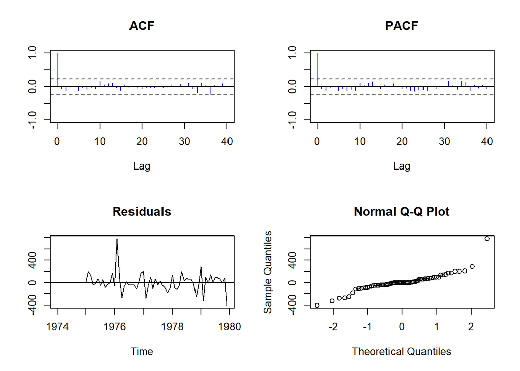

```r
# autofit
test(male_bestmodel$residuals)
```

```r
confint(male_bestmodel)
```

```
            2.5 %     97.5 %
ma1    0.04530122  0.6580219
sar1  -1.27658766 -0.7724459
sar2  -0.76608142 -0.2579470
drift -6.81192800 -2.3219785
```

```
Null hypothesis: Residuals are iid noise.
Test                        Distribution Statistic   p-value
Ljung-Box Q                Q ~ chisq(20)      7.51    0.9947
McLeod-Li Q                Q ~ chisq(20)     12.06    0.9138
Turning points T   (T-46.7)/3.5 ~ N(0,1)        46    0.8503
Diff signs S       (S-35.5)/2.5 ~ N(0,1)        37    0.5431
Rank P           (P-1278)/102.9 ~ N(0,1)      1110    0.1024
```

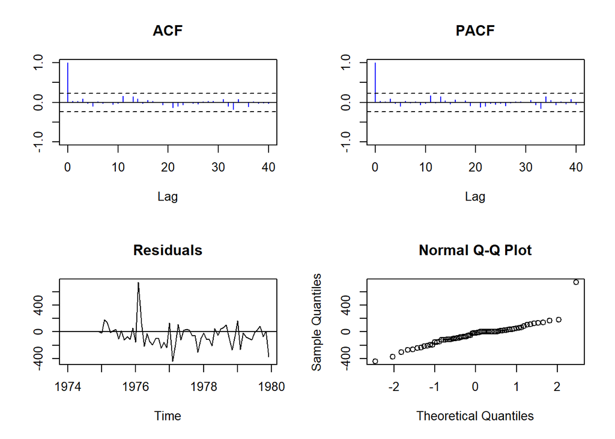

```r
# Fit 1
test(male_fit1$residuals)
```

```r
confint(male_fit1)
```

```
           2.5 %       97.5 %
ma1  -0.17540513  0.481736188
ma2  -0.46554516  0.209699370
ma3  -0.38812544  0.278186540
ma4  -0.22931927  0.442121963
ma5  -0.21896980  0.422396940
ma6  -0.46612692  0.309912944
ma7  -0.29701483  0.287625558
ma8  -0.22073391  0.372984608
ma9  -0.20679189  0.533883837
ma10  0.06619322  0.783643789
sar1 -1.16661350 -0.480236144
sar2 -0.65498413 -0.008335974
```

```
Null hypothesis: Residuals are iid noise.
Test                        Distribution Statistic   p-value
Ljung-Box Q                Q ~ chisq(20)      3.48         1
McLeod-Li Q                Q ~ chisq(20)     15.74    0.7329
Turning points T   (T-46.7)/3.5 ~ N(0,1)        48    0.7058
Diff signs S       (S-35.5)/2.5 ~ N(0,1)        34    0.5431
Rank P           (P-1278)/102.9 ~ N(0,1)      1139    0.1766
```

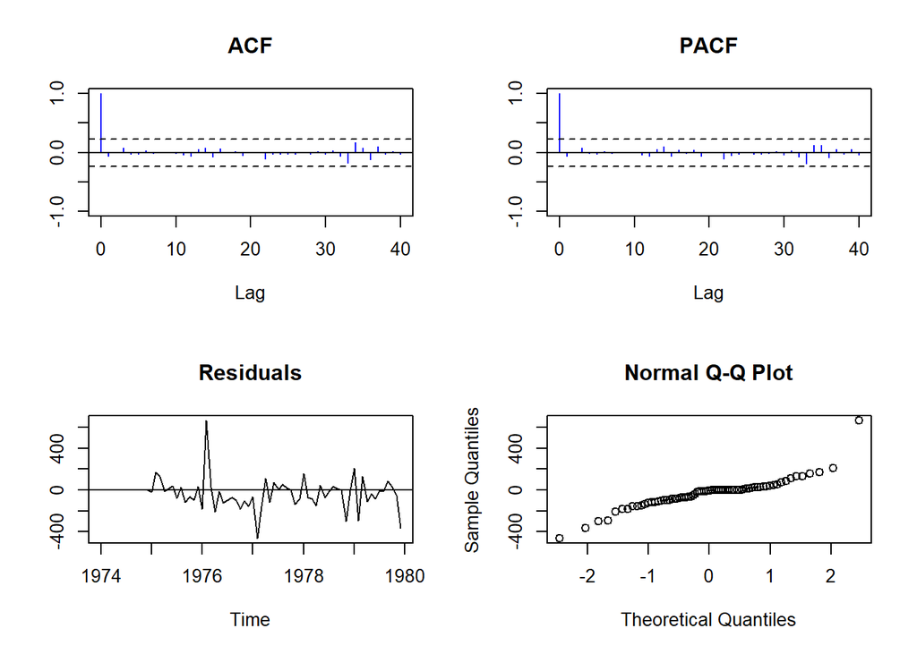

```r
# Fit 2
test(male_fit2$residuals)
```

```r
confint(male_fit2)
```

```
           2.5 %     97.5 %
ma1   0.03308452  0.7243936
ma2  -0.50156520  0.2709541
ma3  -0.69311916  0.2647021
ma4  -0.26255848  0.4283251
ma5  -0.28781974  0.4386188
ma6  -0.51037109  0.3531327
ma7  -0.30344425  0.2729737
ma8  -0.23027814  0.5000244
ma9  -0.28116837  0.4811612
ma10  0.08152954  0.8658694
ma11  0.05934160  0.8493908
ma12 -0.65030239  0.3053885
sar1 -1.08473954 -0.1615119
sar2 -0.57115779  0.1959818
```

```
Null hypothesis: Residuals are iid noise.
Test                        Distribution Statistic   p-value
Ljung-Box Q                Q ~ chisq(20)      8.46    0.9884
McLeod-Li Q                Q ~ chisq(20)     11.66    0.9274
Turning points T   (T-46.7)/3.5 ~ N(0,1)        46    0.8503
Diff signs S       (S-35.5)/2.5 ~ N(0,1)        38    0.3108
Rank P           (P-1278)/102.9 ~ N(0,1)      1115     0.113
```

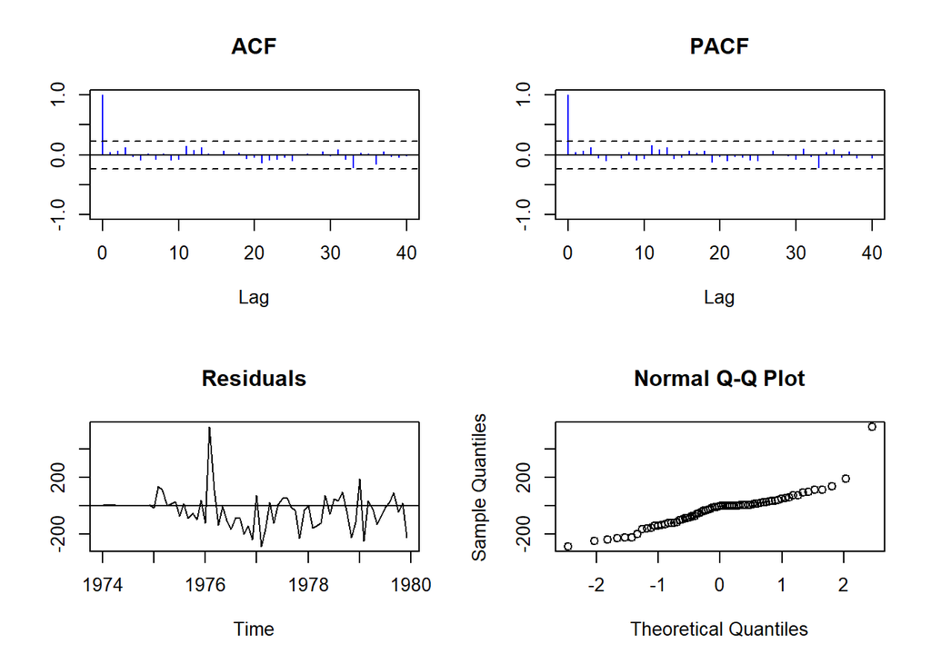

```r
# Fit 3
test(male_fit3$residuals)
```

```r
confint(male_fit3)
```

```
          2.5 %     97.5 %
ma1  -0.1582924  0.3840493
ma2  -0.3788769  0.1434550
ma3  -0.3506996  0.2471369
ma4  -0.1794037  0.3931197
ma5  -0.1428176  0.3589879
ma6  -0.4289481  0.1641970
ma7  -0.2822396  0.2872968
ma8  -0.1612664  0.3280597
ma9  -0.1021284  0.4507820
ma10  0.1912527  0.7977840
sar1 -1.6180432 -1.2660132
sar2 -0.9576708 -0.6549299
sma1  0.3289463  1.6708608
```

## Male Comparison

```r
# Comparison
AIC.values = c(
  m_automodel = male_bestmodel$aic,
  male_fit1 = male_fit1$aic,
  male_fit2 = male_fit2$aic,
  male_fit3 = male_fit3$aic
)
AIC.values
```

```
m_automodel   male_fit1   male_fit2   male_fit3
   807.5325    825.5677    823.2615    822.0774
```

- The best model is: SARIMA(0,0,1)(2,1,0)12

4. Fit a time series model to the training `fdeaths` data set Plot the data, ACF, and PACF. Describe and discuss the steps you followed), and write down the equation of the model.

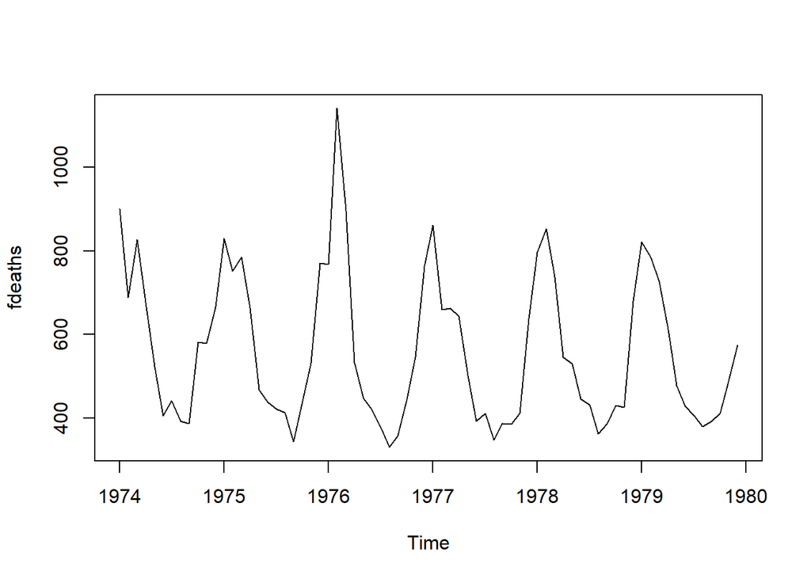

```r
plot(fdeaths)
```

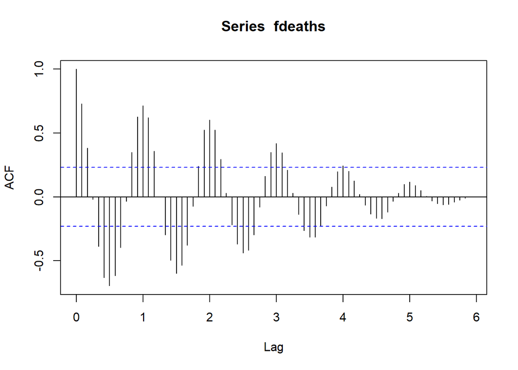

```r
# ACF, PACF
acf(fdeaths, lag.max = 80)
```

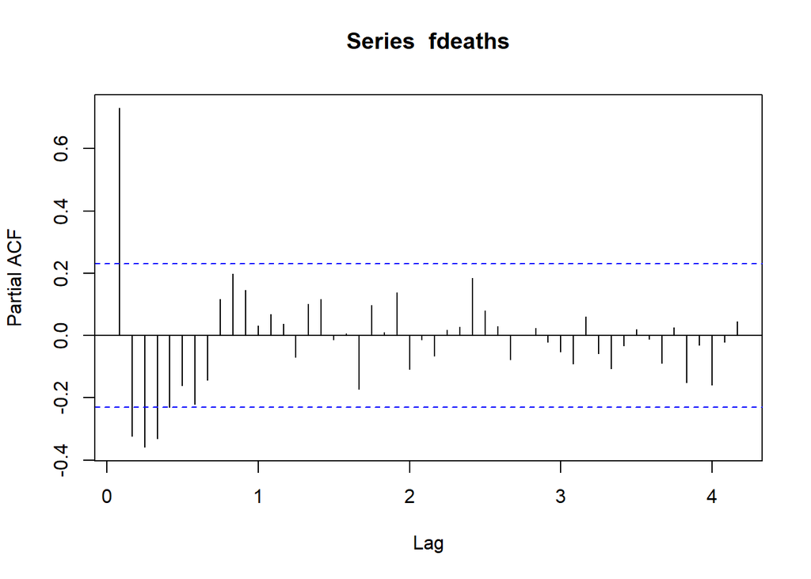

```r
pacf(fdeaths, lag.max = 50)
```

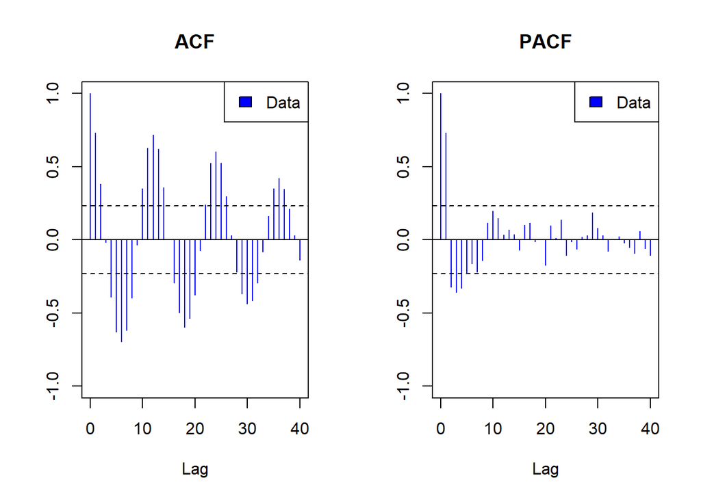

```r
plota(fdeaths)
```

- It seems that there is no trend.
- There is seasonality of 12.
- Overall, no drastic variance change, except in 1976. Further inspection is needed.

```r
# Variance change transformation
lambda = powerTransform(fdeaths)
lambda$roundlam
```

```
fdeaths
      0
```

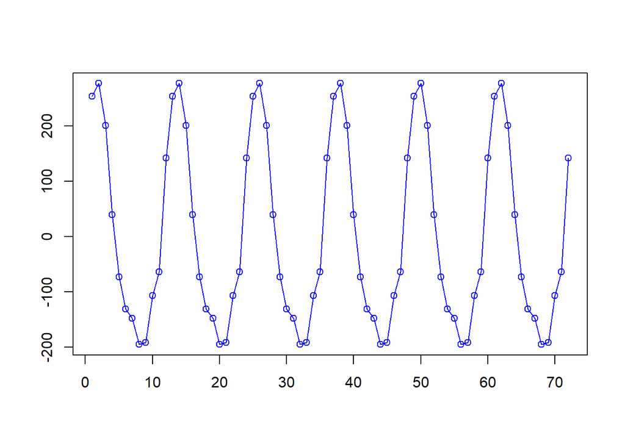

```r
# Seasonality
female_season = season(fdeaths, d=12)
plotc(female_season)
```

## IID Test - Female

```
Null hypothesis: Residuals are iid noise.
Test                        Distribution Statistic   p-value
Ljung-Box Q                Q ~ chisq(20)      50.8     2e-04 *
McLeod-Li Q                Q ~ chisq(20)     42.46    0.0024 *
Turning points T     (T-38)/3.2 ~ N(0,1)        42    0.2097
Diff signs S         (S-29)/2.2 ~ N(0,1)        28    0.6547
Rank P           (P-855.5)/76.5 ~ N(0,1)       846    0.9011
```

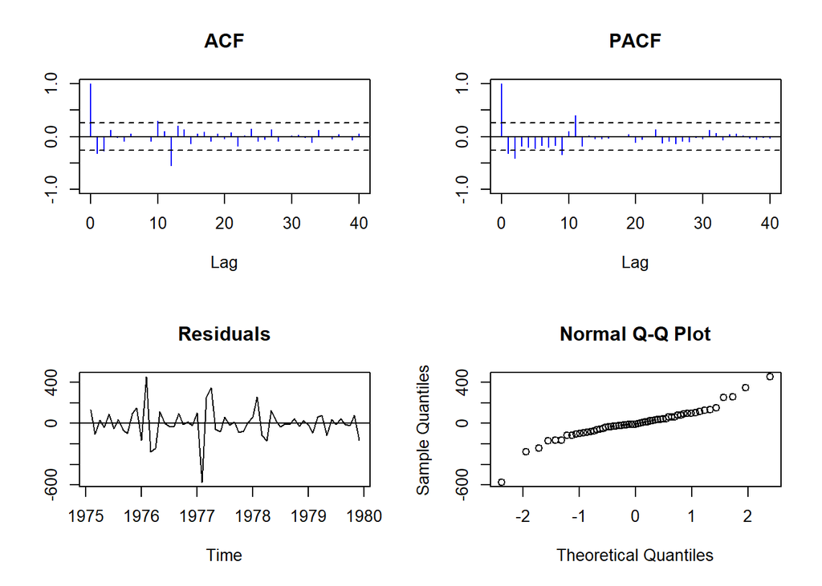

```r
# Differencing Operator
female_diff = c("diff", 12, "diff", 1)

# IID hypothesis test
female_r_diff = Resid(fdeaths, female_diff)
test(female_r_diff)
```

## Stationary Test - Female

```r
# Stationary Test
adf.test(female_r_diff)
```

```
Augmented Dickey-Fuller Test
alternative: stationary

Type 1: no drift no trend
     lag    ADF p.value
[1,]   0 -10.50    0.01
[2,]   1  -9.39    0.01
[3,]   2  -6.88    0.01
[4,]   3  -6.06    0.01
Type 2: with drift no trend
     lag    ADF p.value
[1,]   0 -10.40    0.01
[2,]   1  -9.30    0.01
[3,]   2  -6.81    0.01
[4,]   3  -6.00    0.01
Type 3: with drift and trend
     lag    ADF p.value
[1,]   0 -10.31    0.01
[2,]   1  -9.21    0.01
[3,]   2  -6.74    0.01
[4,]   3  -5.94    0.01
----
Note: in fact, p.value = 0.01 means p.value <= 0.01
```

### Based on the PACF - Female

P = 0, 1:4, 10

p = 0,1

### Based on the ACF - Female

q = 0, 1, 2, 4:8, 10:14

Q = 0,1:3

### Eliminate Season - Female

d = 0 (differencing non-seasonal)

D = 1 (differencing seasonal)

## Autofit - Female

```r
# Auto fit
female_bestmodel = auto.arima(fdeaths, trace = T)
```

```
 ARIMA(2,0,2)(1,1,1)[12] with drift         : Inf
 ARIMA(0,0,0)(0,1,0)[12] with drift         : 735.0779
 ARIMA(1,0,0)(1,1,0)[12] with drift         : 717.9657
 ARIMA(0,0,1)(0,1,1)[12] with drift         : Inf
 ARIMA(0,0,0)(0,1,0)[12]                    : 733.4053
 ARIMA(1,0,0)(0,1,0)[12] with drift         : 736.8396
 ARIMA(1,0,0)(2,1,0)[12] with drift         : 710.3874
 ARIMA(1,0,0)(2,1,1)[12] with drift         : Inf
 ARIMA(1,0,0)(1,1,1)[12] with drift         : Inf
 ARIMA(0,0,0)(2,1,0)[12] with drift         : 708.4859
 ARIMA(0,0,0)(1,1,0)[12] with drift         : 716.0469
 ARIMA(0,0,0)(2,1,1)[12] with drift         : Inf
 ARIMA(0,0,0)(1,1,1)[12] with drift         : Inf
 ARIMA(0,0,1)(2,1,0)[12] with drift         : 710.098
 ARIMA(1,0,1)(2,1,0)[12] with drift         : 711.498
 ARIMA(0,0,0)(2,1,0)[12]                    : 710.8345

 Best model: ARIMA(0,0,0)(2,1,0)[12] with drift
```

## Fit Models - Female

```r
# Fit 1
female_fit1 = arima(fdeaths,
             order = c(0,0,10),
             seasonal = list(order=c(2,1,0), period=12))

# Fit 2
female_fit2 = arima(fdeaths,
             order = c(0,0,12),
             seasonal = list(order=c(2,1,0), period=12))

# Fit 3
female_fit3 = arima(fdeaths,
             order = c(0,0,11),
             seasonal = list(order=c(2,1,1), period=12))
```

## Test Residuals from Female SARIMA models

```
Null hypothesis: Residuals are iid noise.
Test                        Distribution Statistic   p-value
Ljung-Box Q                Q ~ chisq(20)      9.97    0.9687
McLeod-Li Q                Q ~ chisq(20)      3.31         1
Turning points T   (T-46.7)/3.5 ~ N(0,1)        50    0.3453
Diff signs S       (S-35.5)/2.5 ~ N(0,1)        33    0.3108
Rank P           (P-1278)/102.9 ~ N(0,1)      1363    0.4086
```

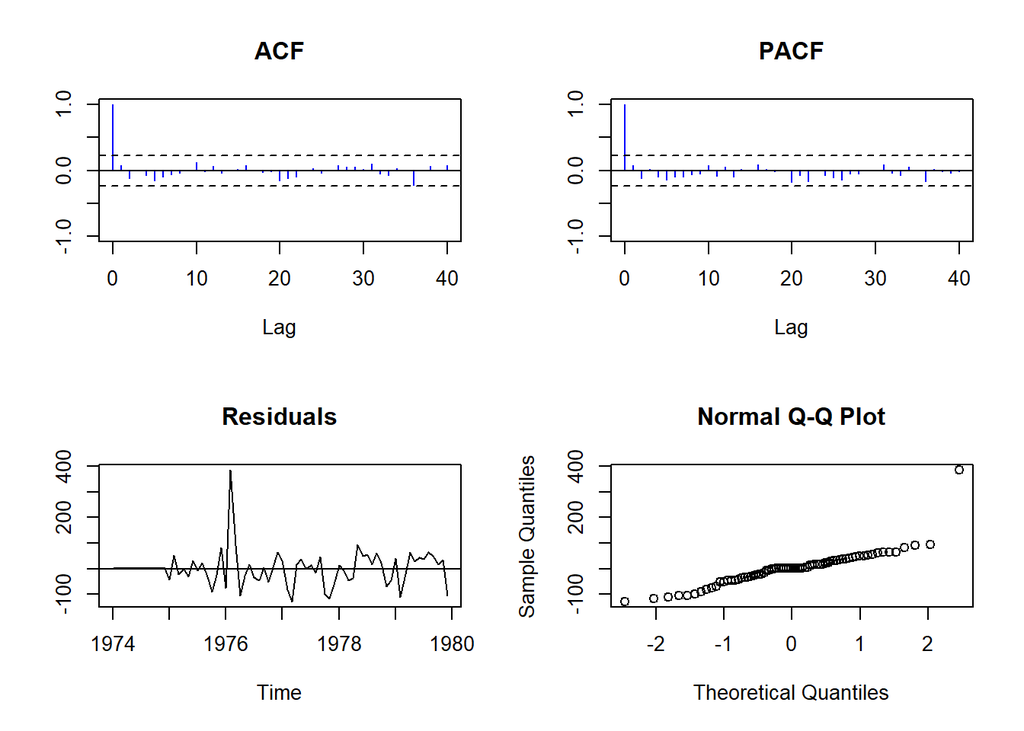

```r
# autofit
test(female_bestmodel$residuals)
```

```r
confint(female_bestmodel)
```

```
           2.5 %     97.5 %
sar1  -1.1202669 -0.6240201
sar2  -0.7494315 -0.2405313
drift -1.7753760 -0.1530185
```

```
Null hypothesis: Residuals are iid noise.
Test                        Distribution Statistic   p-value
Ljung-Box Q                Q ~ chisq(20)       5.7    0.9992
McLeod-Li Q                Q ~ chisq(20)      3.15         1
Turning points T   (T-46.7)/3.5 ~ N(0,1)        50    0.3453
Diff signs S       (S-35.5)/2.5 ~ N(0,1)        31    0.0681
Rank P           (P-1278)/102.9 ~ N(0,1)      1266    0.9071
```

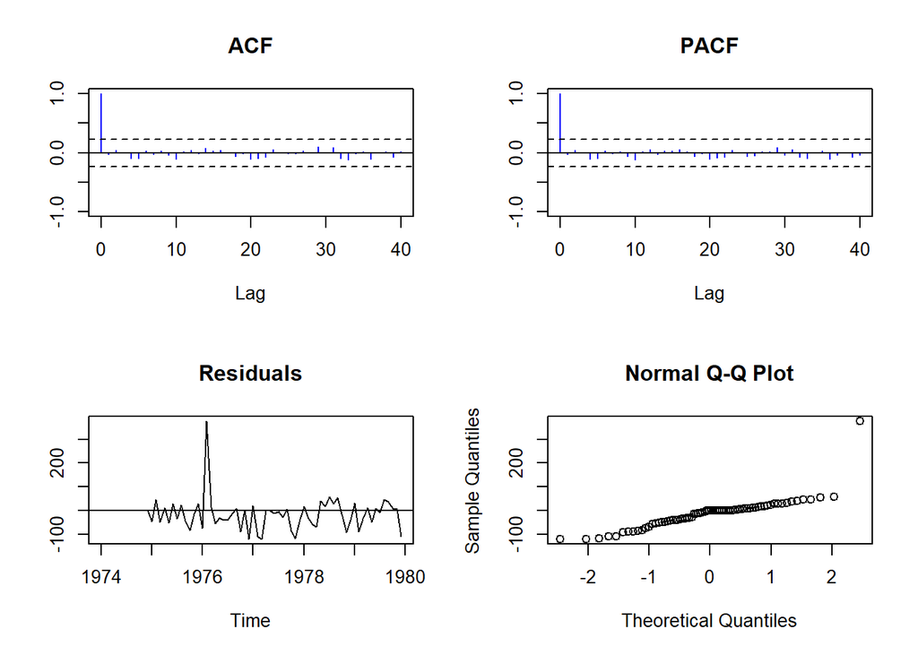

```r
# Fit 1
test(female_fit1$residuals)
```

```r
confint(female_fit1)
```

```
           2.5 %     97.5 %
ma1  -0.18517359  0.3655409
ma2  -0.40224074  0.1517299
ma3  -0.21465818  0.4350243
ma4  -0.20145115  0.4608645
ma5  -0.34091506  0.2308684
ma6  -0.52642856  0.1761209
ma7  -0.40446044  0.2151572
ma8  -0.20453638  0.3643207
ma9  -0.22878353  0.4201261
ma10  0.03309285  0.6397694
sar1 -1.13452867 -0.5774834
sar2 -0.73933700 -0.1721855
```

```
Null hypothesis: Residuals are iid noise.
Test                        Distribution Statistic   p-value
Ljung-Box Q                Q ~ chisq(20)      8.75    0.9856
McLeod-Li Q                Q ~ chisq(20)      2.85         1
Turning points T   (T-46.7)/3.5 ~ N(0,1)        46    0.8503
Diff signs S       (S-35.5)/2.5 ~ N(0,1)        34    0.5431
Rank P           (P-1278)/102.9 ~ N(0,1)      1260    0.8611
```

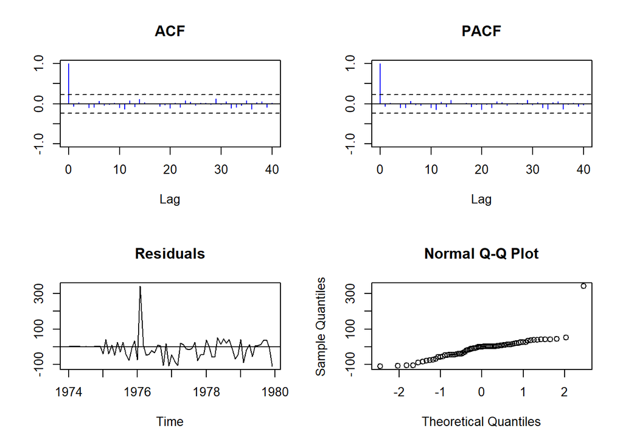

```r
# Fit 2
test(female_fit2$residuals)
```

```r
confint(female_fit2)
```

```
           2.5 %     97.5 %
ma1  -0.25365565  0.6760752
ma2  -0.42666391  0.3632877
ma3  -0.68371833  0.7458796
ma4  -0.36677194  0.7934477
ma5  -0.36666461  0.4366707
ma6  -0.98329617  0.2885128
ma7  -0.51891022  0.3095258
ma8  -0.20761934  0.5840620
ma9  -0.37431521  0.3533581
ma10 -0.05849743  0.8682956
ma11 -0.07694972  0.7485503
ma12 -0.55533081  0.3916342
sar1 -1.19928047 -0.4009250
sar2 -0.78862950 -0.1125481
```

```
Null hypothesis: Residuals are iid noise.
Test                        Distribution Statistic   p-value
Ljung-Box Q                Q ~ chisq(20)      8.05    0.9915
McLeod-Li Q                Q ~ chisq(20)      3.99         1
Turning points T   (T-46.7)/3.5 ~ N(0,1)        50    0.3453
Diff signs S       (S-35.5)/2.5 ~ N(0,1)        36    0.8394
Rank P           (P-1278)/102.9 ~ N(0,1)      1255    0.8231
```

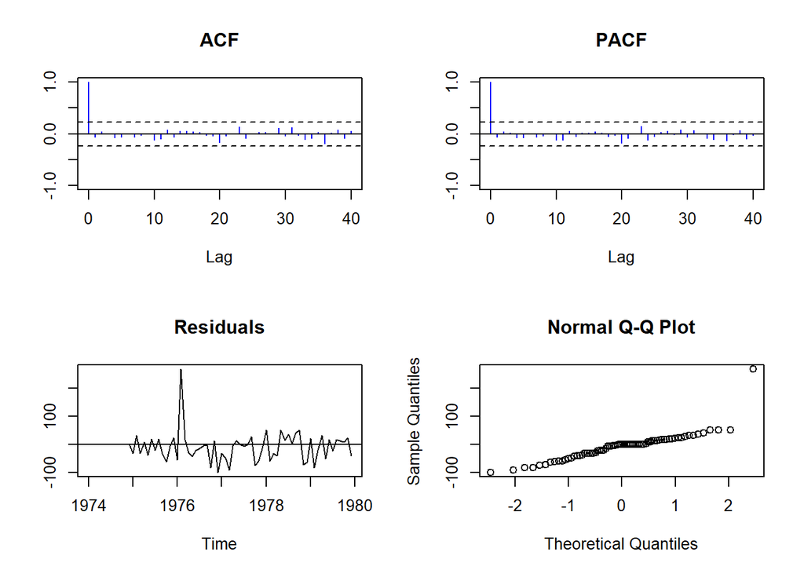

```r
# Fit 3
test(female_fit3$residuals)
```

```r
confint(female_fit3)
```

```
          2.5 %     97.5 %
ma1  -0.1974321  0.4128638
ma2  -0.3614749  0.1896460
ma3  -0.1844693  0.4813533
ma4  -0.1608415  0.4391140
ma5  -0.3575794  0.1790069
ma6  -0.5209014  0.1254685
ma7  -0.3671146  0.1528365
ma8  -0.2088927  0.4024478
ma9  -0.2566027  0.3278581
ma10  0.1749769  0.7086993
ma11 -0.1187750  0.6204316
sar1 -1.5171675 -1.2438530
sar2 -0.9543478 -0.6914473
sma1  0.3038746  1.6959568
```

## Female Comparison

```r
# Comparison
AIC.values = c(
  f_automodel = female_bestmodel$aic,
  female_fit1 = female_fit1$aic,
  female_fit2 = female_fit2$aic,
  female_fit3 = female_fit3$aic
)
AIC.values
```

```
f_automodel female_fit1 female_fit2 female_fit3
   707.7587    721.3894    723.2997    719.7837
```

- The best model is: SARIMA(0,0,0)(2,1,0)12

## Total Deaths Forecast

```r
# AutoFit
t_automodel_forecast  = auto.arima(death_training_ts, trace= T, seasonal = T)
```

```
 ARIMA(2,0,2)(1,1,1)[12] with drift         : Inf
 ARIMA(0,0,0)(0,1,0)[12] with drift         : 710.8576
 ARIMA(1,0,0)(1,1,0)[12] with drift         : 697.6284
 ARIMA(0,0,1)(0,1,1)[12] with drift         : Inf
 ARIMA(0,0,0)(0,1,0)[12]                    : 709.3627
 ARIMA(1,0,0)(0,1,0)[12] with drift         : 712.5726
 ARIMA(1,0,0)(1,1,1)[12] with drift         : Inf
 ARIMA(1,0,0)(0,1,1)[12] with drift         : Inf
 ARIMA(0,0,0)(1,1,0)[12] with drift         : 696.8401
 ARIMA(0,0,0)(1,1,1)[12] with drift         : Inf
 ARIMA(0,0,0)(0,1,1)[12] with drift         : Inf
 ARIMA(0,0,1)(1,1,0)[12] with drift         : 695.377
 ARIMA(0,0,1)(0,1,0)[12] with drift         : 711.7052
 ARIMA(0,0,1)(1,1,1)[12] with drift         : Inf
 ARIMA(1,0,1)(1,1,0)[12] with drift         : 696.5302
 ARIMA(0,0,2)(1,1,0)[12] with drift         : 694.7447
 ARIMA(0,0,2)(0,1,0)[12] with drift         : 709.5547
 ARIMA(0,0,2)(1,1,1)[12] with drift         : Inf
 ARIMA(0,0,2)(0,1,1)[12] with drift         : Inf
 ARIMA(1,0,2)(1,1,0)[12] with drift         : Inf
 ARIMA(0,0,3)(1,1,0)[12] with drift         : 695.0132
 ARIMA(1,0,3)(1,1,0)[12] with drift         : Inf
 ARIMA(0,0,2)(1,1,0)[12]                    : 696.3113

 Best model: ARIMA(0,0,2)(1,1,0)[12] with drift
```

```r
# Fit 1
total_forecast_1 = arima(death_training_ts,
             order = c(0,0,10),
             seasonal = list(order=c(2,1,0), period=12))

# Fit 2
total_forecast_2 = arima(death_training_ts,
             order = c(0,0,12),
             seasonal = list(order=c(2,1,0), period=12))

# Fit 3
total_forecast_3 = arima(death_training_ts,
             order = c(0,0,10),
             seasonal = list(order=c(2,1,1), period=12))
```

```r
best_total_forecast = arima(death_training_ts,
             order = c(0,0,2),
             seasonal = list(order=c(1,1,0), period=12))
total.auto = aTSA::forecast(object = best_total_forecast,lead = 12, output = FALSE)
```

## Male Deaths Forecast

```r
# AutoFit
m_automodel_forecast  = auto.arima(male_training_ts, trace= T, seasonal = T)
```

```
 ARIMA(2,0,2)(1,1,1)[12] with drift         : Inf
 ARIMA(0,0,0)(0,1,0)[12] with drift         : 678.0696
 ARIMA(1,0,0)(1,1,0)[12] with drift         : 664.6942
 ARIMA(0,0,1)(0,1,1)[12] with drift         : Inf
 ARIMA(0,0,0)(0,1,0)[12]                    : 676.7469
 ARIMA(1,0,0)(0,1,0)[12] with drift         : 679.7523
 ARIMA(1,0,0)(1,1,1)[12] with drift         : Inf
 ARIMA(1,0,0)(0,1,1)[12] with drift         : Inf
 ARIMA(0,0,0)(1,1,0)[12] with drift         : 664.5295
 ARIMA(0,0,0)(1,1,1)[12] with drift         : Inf
 ARIMA(0,0,0)(0,1,1)[12] with drift         : Inf
 ARIMA(0,0,1)(1,1,0)[12] with drift         : 661.0822
 ARIMA(0,0,1)(0,1,0)[12] with drift         : 678.6863
 ARIMA(0,0,1)(1,1,1)[12] with drift         : Inf
 ARIMA(1,0,1)(1,1,0)[12] with drift         : Inf
 ARIMA(0,0,2)(1,1,0)[12] with drift         : 660.6509
 ARIMA(0,0,2)(0,1,0)[12] with drift         : 676.1388
 ARIMA(0,0,2)(1,1,1)[12] with drift         : Inf
 ARIMA(0,0,2)(0,1,1)[12] with drift         : Inf
 ARIMA(1,0,2)(1,1,0)[12] with drift         : Inf
 ARIMA(0,0,3)(1,1,0)[12] with drift         : 661.0468
 ARIMA(1,0,3)(1,1,0)[12] with drift         : 663.7802
 ARIMA(0,0,2)(1,1,0)[12]                    : 662.8813

 Best model: ARIMA(0,0,2)(1,1,0)[12] with drift
```

```r
# Fit 1
male_forecast_1 = arima(female_training_ts,
             order = c(0,0,10),
             seasonal = list(order=c(2,1,0), period=12))

# Fit 2
male_forecast_2 = arima(female_training_ts,
             order = c(0,0,12),
             seasonal = list(order=c(2,1,0), period=12))

# Fit 3
male_forecast_3 = arima(female_training_ts,
             order = c(0,0,10),
             seasonal = list(order=c(2,1,1), period=12))
```

```r
best_male_forecast = arima(male_training_ts,
             order = c(0,0,2),
             seasonal = list(order=c(1,1,0), period=12))
m.auto = aTSA::forecast(object = best_male_forecast,lead = 12, output = FALSE)
```

```r
m1  = aTSA::forecast(object = male_forecast_1,lead = 12,output = FALSE)
m2  = aTSA::forecast(object = male_forecast_2,lead = 12,output = FALSE)
m3  = aTSA::forecast(object = male_forecast_3,lead = 12,output = FALSE)
```

## Female Deaths Forecast

```r
# AutoFit
f_automodel_forecast  = auto.arima(female_training_ts, trace= T, seasonal = T)
```

```
 ARIMA(2,0,2)(1,1,1)[12] with drift         : Inf
 ARIMA(0,0,0)(0,1,0)[12] with drift         : 597.6899
 ARIMA(1,0,0)(1,1,0)[12] with drift         : 585.4855
 ARIMA(0,0,1)(0,1,1)[12] with drift         : Inf
 ARIMA(0,0,0)(0,1,0)[12]                    : 595.813
 ARIMA(1,0,0)(0,1,0)[12] with drift         : 599.423
 ARIMA(1,0,0)(1,1,1)[12] with drift         : Inf
 ARIMA(1,0,0)(0,1,1)[12] with drift         : Inf
 ARIMA(0,0,0)(1,1,0)[12] with drift         : 583.4451
 ARIMA(0,0,0)(1,1,1)[12] with drift         : Inf
 ARIMA(0,0,0)(0,1,1)[12] with drift         : Inf
 ARIMA(0,0,1)(1,1,0)[12] with drift         : 585.2397
 ARIMA(1,0,1)(1,1,0)[12] with drift         : 586.9259
 ARIMA(0,0,0)(1,1,0)[12]                    : 582.633
 ARIMA(0,0,0)(1,1,1)[12]                    : Inf
 ARIMA(0,0,0)(0,1,1)[12]                    : Inf
 ARIMA(1,0,0)(1,1,0)[12]                    : 584.3467
 ARIMA(0,0,1)(1,1,0)[12]                    : 584.0316
 ARIMA(1,0,1)(1,1,0)[12]                    : 585.7067

 Best model: ARIMA(0,0,0)(1,1,0)[12]
```

```r
# Fit 1
female_forecast_1 = arima(female_training_ts,
             order = c(0,0,10),
             seasonal = list(order=c(2,1,0), period=12))

# Fit 2
female_forecast_2 = arima(female_training_ts,
             order = c(0,0,12),
             seasonal = list(order=c(2,1,0), period=12))

# Fit 3
female_forecast_3 = arima(female_training_ts,
             order = c(0,0,11),
             seasonal = list(order=c(2,1,1), period=12))
```

```r
best_female_forecast = arima(female_training_ts,
             order = c(0,0,0),
             seasonal = list(order=c(1,1,0), period=12))
f.auto = aTSA::forecast(object = best_female_forecast,lead = 12, output = FALSE)
```

```r
f1  = aTSA::forecast(object = female_forecast_1,lead = 12,output = FALSE)
f2  = aTSA::forecast(object = female_forecast_2,lead = 12,output = FALSE)
f3  = aTSA::forecast(object = female_forecast_3,lead = 12,output = FALSE)
```

6. Fit ARAR and Holt-Winters models to the three time series data (ldeaths, fdeaths, and mdeaths)

```
Optimal lags 1 10 12 24
Optimal coeffs 0.07344124 0.1835476 -0.6012546 -0.2809034
WN Variance 89122.12
Filter 1 -0.07344124 0 0 0 0 0 0 0 0 -0.1835476 0 -0.3671471 0.07112063 0 0 0 0 0 0 0 0 0.1777478 0 -0.3013526 0 0 0 0 0 0 0 0 0 0 0 -0.2720274

 Step     Prediction      sqrt(MSE)    Lower Bound    Upper Bound
    1       2848.254       298.5333       2263.129       3433.379
    2       2871.607       299.3373       2284.906       3458.308
    3       2621.549       299.3416       2034.839       3208.258
    4       2066.117       299.3416       1479.408       2652.827
    5       1718.587       299.3416       1131.877       2305.296
    6       1533.828       299.3416       947.1185       2120.538
    7       1458.316       299.3416        871.606       2045.025
    8        1307.97       299.3416       721.2599       1894.679
    9       1295.997       299.3416       709.2869       1882.706
   10       1579.849       299.3416       993.1392       2166.558
   11       1666.318       304.3155       1069.859       2262.776
   12       2390.327       304.4219        1793.66       2986.994
```

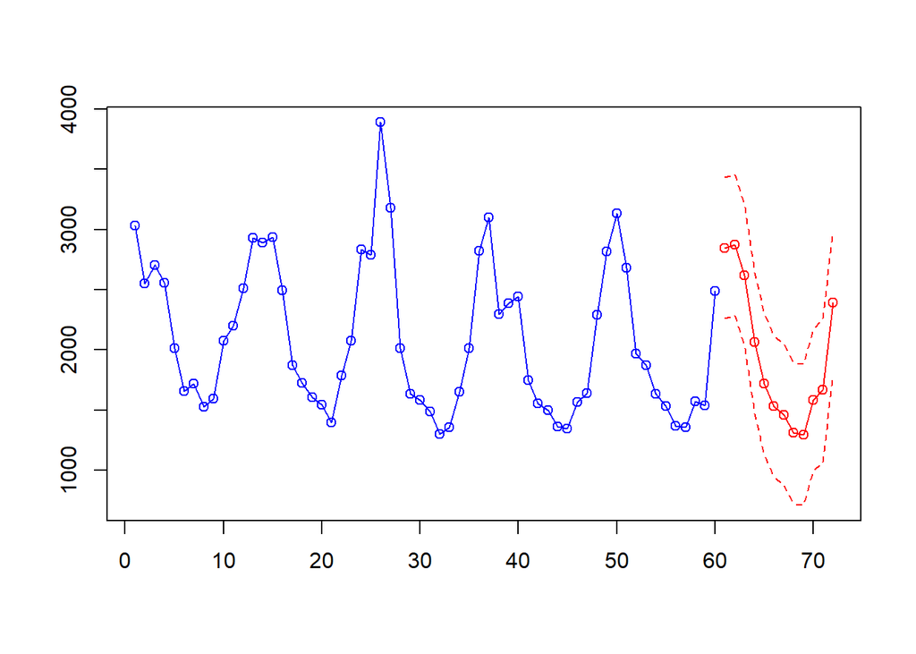

```r
# ARAR
# total
#male
arar.total = arar(death_training_ts, h=12)
```

```
Optimal lags 1 10 12 24
Optimal coeffs 0.07736416 0.2101178 -0.5613554 -0.2765714
WN Variance 45802.66
Filter 1 -0.07736416 0 0 0 0 0 0 0 0 -0.2101178 0 -0.4068521 0.07490456 0 0 0 0 0 0 0 0 0.2034376 0 -0.2669371 0 0 0 0 0 0 0 0 0 0 0 -0.2677786

 Step     Prediction      sqrt(MSE)    Lower Bound    Upper Bound
    1       2053.897       214.0156       1634.426       2473.367
    2       2061.753       214.6551       1641.029       2482.477
    3       1897.274       214.6589       1476.543       2318.005
    4       1489.745       214.6589       1069.014       1910.477
    5       1234.075       214.6589       813.3438       1654.807
    6       1123.379       214.6589       702.6478       1544.111
    7       1061.302       214.6589       640.5702       1482.033
    8       957.8396       214.6589       537.1081       1378.571
    9       919.9189       214.6589       499.1875        1340.65
   10       1164.227       214.6589       743.4955       1584.958
   11       1217.665       219.3185       787.8011        1647.53
   12       1729.637       219.4289       1299.556       2159.717
```

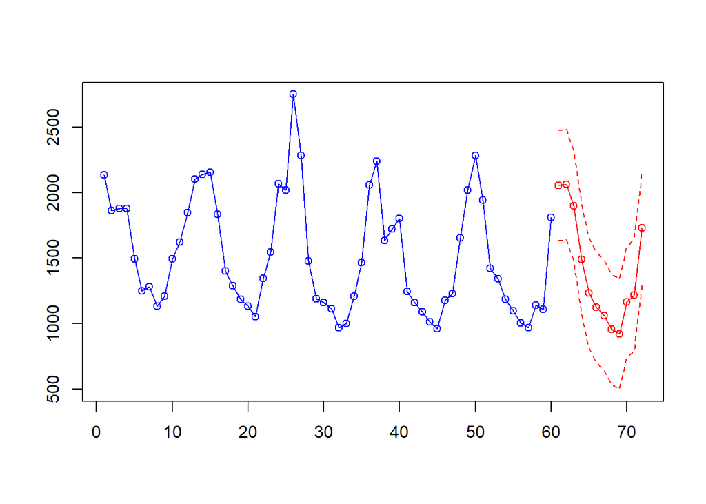

```r
#male
arar.male = arar(male_training_ts, h=12)
```

```
Optimal lags 1 10 12 24
Optimal coeffs 0.05238724 0.1330045 -0.6484616 -0.2602666
WN Variance 8408.787
Filter 1 -0.05238724 0 0 0 0 0 0 0 0 -0.1330045 0 -0.3174993 0.05060402 0 0 0 0 0 0 0 0 0.1284771 0 -0.3661219 0 0 0 0 0 0 0 0 0 0 0 -0.2514074

 Step     Prediction      sqrt(MSE)    Lower Bound    Upper Bound
    1       794.5343       91.69944       614.8034       974.2652
    2       807.9243       91.82518       627.9469       987.9016
    3       724.4022       91.82553       544.4241       904.3802
    4       569.3797       91.82553       389.4017       749.3578
    5        488.415       91.82553       308.4369        668.393
    6       410.1685       91.82553       230.1905       590.1466
    7       399.7666       91.82553       219.7885       579.7446
    8        349.419       91.82553       169.4409        529.397
    9       375.2719       91.82553       195.2938       555.2499
   10       415.0241       91.82553        235.046       595.0021
   11       443.3216       92.63197       261.7629       624.8803
   12       658.0761       92.64078       476.5001        839.652
```

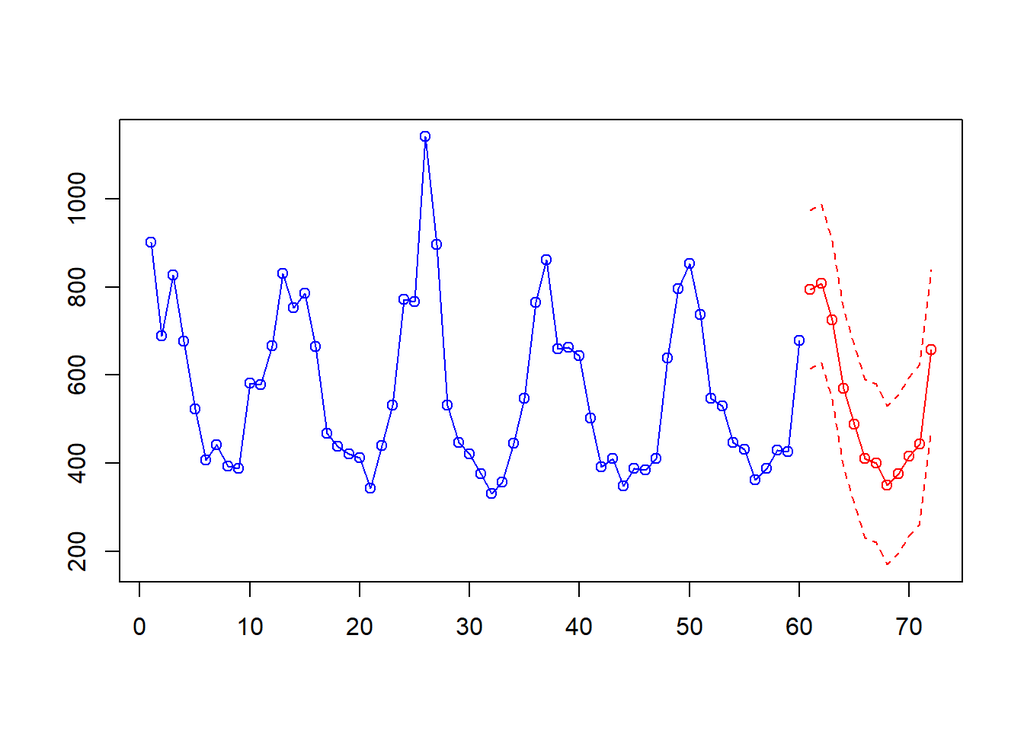

```r
# female
arar.female = arar(female_training_ts, h=12)
```

```r
# Holt-Winters
# total
total_HWmodel = HoltWinters(death_training_ts,seasonal = "mult")
HW.prd =forecast::forecast(total_HWmodel,12)
# male
m_HWmodel = HoltWinters(male_training_ts,seasonal = "mult")
HW.prd =forecast::forecast(m_HWmodel,12)
# female
f_HWmodel = HoltWinters(female_training_ts,seasonal = "mult")
HW.prd =forecast::forecast(f_HWmodel,12)
```

7. Combine the forecasts of male and female deaths. Let’s name it CombinedForecasting= MaleForecasts+ FemaleForecasts. This CombinedForecasting could be used to forecast the total monthly deaths.

```r
library(Metrics)
CombinedForecast = m.auto + f.auto
```

8. Compare the forecasting performance of the CombinedForecast, the OneModelForecasts (using the model on `ldeaths`) and fill out the below table. Comments on the results of this analysis and the merit of combined forecasts.

[output not shown]